# Intro to Random Forests

September 15, 2020

## Overview

1. Background

   Trees vs. Forsets; Random Forest Algorithm; Advatanges / Distadvantages
2. Basic Implementation

   Dataset & research problem; Model basics & key terms (OOB error & parameters); Tuning; Prediction; Variable Importance
3. Gotchas

   Imbalanced samples; Variable importance validation; Multicollinearity
4. Resources & further reading

## Trees vs Forests

| Decision Tree | Random Forest |
| --- | --- |
| Single tree | Collection of different trees |
| Uses entire dataset | Uses boostrapped data |
| Uses all features | Uses subsets of features |
| One tree determines prediction | All trees contribute to prediction |

## Random Forest Algorithm

The basic algorithm for a regression random forest can be generalized to the following:

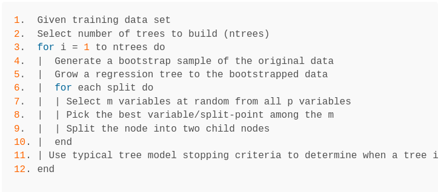

(from [UC Business Analytics R Programming Guide](https://uc-r.github.io/random_forests))

## Advantages & Disadvantages

| Advantages | Disadvantages |
| --- | --- |
| Good performance | Advanced boosting algorithms can perform better |
| “out-of-the box” | Slow on large data sets |
| Built-in validation set | Not very interpretable |
| Robust to outliers |  |

## Basic Implementation

## The Case of the Mondays (COTM)

[figure not shown]

## Dataset

Ficticious scientists conducted a ficticious survey of 1000 ficticious people, collecting the following variables of interest:

- Age
- Weekly routine (does the person have a regular routine of school/work or not?)
- How much fun is had on weekends
- Alcohol consumption on weekends
- How much work, boss and colleagues are liked
- How much work stress is experienced
- Health, Financial and Social support status

## Who will get COTM?

## Train & Test Samples

```r
set.seed(123)   # for reproduciblity

train <- sample(1:nrow(df), .67*nrow(df))

df_train <- df[train,]
df_test <- df[-train,]
```

[figure not shown]

## Model

```r
# library(randomForest)
set.seed(123)   # for reproduciblity

rf <- randomForest(formula =  cotm ~ ., data  = df_train,
                   importance = TRUE)
rf
```

```
##
## Call:
##  randomForest(formula = cotm ~ ., data = df_train, importance = TRUE)
##                Type of random forest: classification
##                      Number of trees: 500
## No. of variables tried at each split: 3
##
##         OOB estimate of  error rate: 8.36%
## Confusion matrix:
##     0  1 class.error
## 0 601  7  0.01151316
## 1  49 13  0.79032258
```

## Model Parameters

```r
set.seed(123)   # for reproduciblity

rf_formula = paste0("cotm ~ ",
                    paste0(colnames(df[,-2]), collapse = " + "))

rf1 <- randomForest(formula =  as.formula(rf_formula),
                   data  = df_train,
                   ntree = 300,   # number of trees
                   mtry = 2,      # number of vars sampled per split
                   sampsize = 400, # size of samples to draw
                   nodesize = 3, # minimum number of terminal nodes
                   importance = TRUE)   # keep importance values of variables
```

## Tuning

(see [UC Business Analytics tutorial](https://uc-r.github.io/random_forests#tune) and [Julia Silge’s tutorial](https://juliasilge.com/blog/sf-trees-random-tuning/) for more info on tuning)

```r
# library(ranger)

# hyperparameter grid search
hyper_grid <- expand.grid(
  num_trees = seq(400,600, by = 50),
  mtry       = seq(2, 11, by = 2),
  node_size  = seq(3, 9, by = 2),
  sample_size = c(.55, .632, .70, .80),
  OOB_RMSE   = 0
)
```

Total number of combinations: 400

## Tuning

```r
for(i in 1:nrow(hyper_grid)) {

  # train model
  model <- ranger(
    formula         = cotm ~ .,
    data            = df_train,
    num.trees       = hyper_grid$num_trees[i],
    mtry            = hyper_grid$mtry[i],
    min.node.size   = hyper_grid$node_size[i],
    sample.fraction = hyper_grid$sample_size[i],
    seed            = 123
  )

  # add OOB error to grid
  hyper_grid$OOB_RMSE[i] <- sqrt(model$prediction.error)
}
```

## Tuning

```r
hyper_grid <- hyper_grid %>%
  dplyr::arrange(OOB_RMSE)

head(hyper_grid, 5)
```

```
##   num_trees mtry node_size sample_size  OOB_RMSE
## 1       400    8         9        0.55 0.2676598
## 2       450    8         9        0.55 0.2704336
## 3       550    6         9        0.55 0.2731792
## 4       400   10         9        0.55 0.2731792
## 5       600   10         9        0.70 0.2731792
```

## Tuning

```r
set.seed(123)
rf2 <- randomForest(formula = as.formula(rf_formula), data  = df_train,
                   ntree = hyper_grid$num_trees[1], mtry = hyper_grid$mtry[1],
                   sampsize = ceiling(hyper_grid$sample_size[1]*nrow(df)),
                   nodesize = hyper_grid$node_size[1], importance = TRUE)
rf2
```

```
##
## Call:
##  randomForest(formula = as.formula(rf_formula), data = df_train,      ntree = hyper_grid$num_trees[1], mtry = hyper_grid$mtry[1],      sampsize = ceiling(hyper_grid$sample_size[1] * nrow(df)),      nodesize = hyper_grid$node_size[1], importance = TRUE)
##                Type of random forest: classification
##                      Number of trees: 400
## No. of variables tried at each split: 8
##
##         OOB estimate of  error rate: 7.46%
## Confusion matrix:
##     0  1 class.error
## 0 600  8  0.01315789
## 1  42 20  0.67741935
```

## Prediction

```r
predicted_values <- predict(rf2, df_test)
confusionMatrix(predicted_values, df_test$cotm)$table
```

```
##           Reference
## Prediction   0   1
##          0 290  25
##          1   2  13
```

## Variable importance: Accuracy

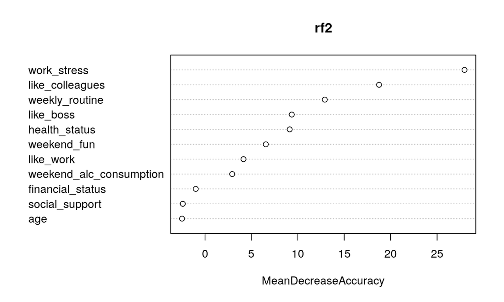

```r
# For each variable, scramble values (maintain distribution); build a tree;
# assess accuracy and loss of accuracy as a result of scrambling.
varImpPlot(rf2, type = 1)
```

## Variable importance: Gini

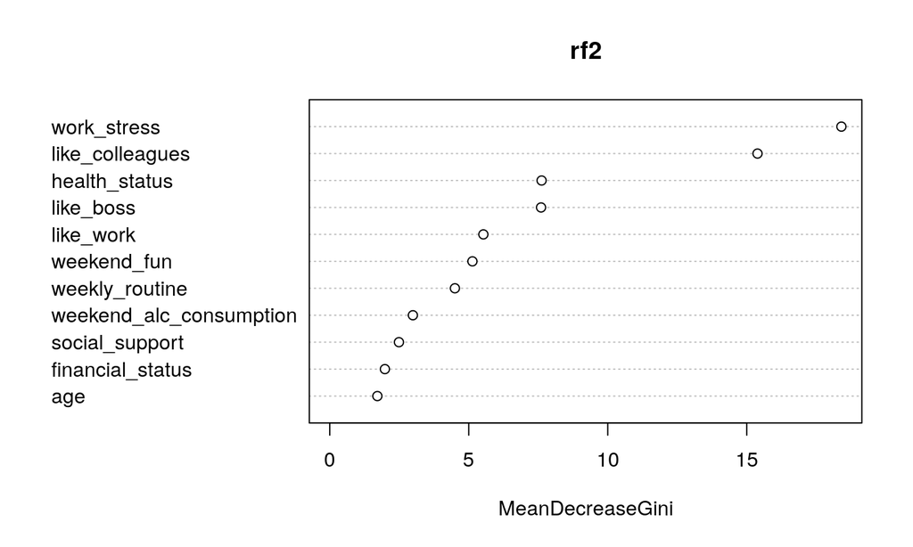

```r
# If the variable is useful, it will split mixed labeled nodes into
# pure single class nodes. Gini index is an indicator of node 'purity'.
varImpPlot(rf2, type = 2)
```

## Gotchas

## Imbalanced samples

```r
set.seed(123)
rf <- randomForest(formula =  cotm ~ ., data  = df_train_balanced)
rf
```

```
##
## Call:
##  randomForest(formula = cotm ~ ., data = df_train_balanced)
##                Type of random forest: classification
##                      Number of trees: 500
## No. of variables tried at each split: 3
##
##         OOB estimate of  error rate: 17.74%
## Confusion matrix:
##    0  1 class.error
## 0 51 11   0.1774194
## 1 11 51   0.1774194
```

## Some solutions

(see [this tech report](https://statistics.berkeley.edu/sites/default/files/tech-reports/666.pdf) for additional info)

1. Balance data via under/over sampling
2. Add weights to random forest model
3. Quantile-classifer (RFQ) approach

Package `randomForestSRC` has implementations for 2 & 3

## Validation of variable importance

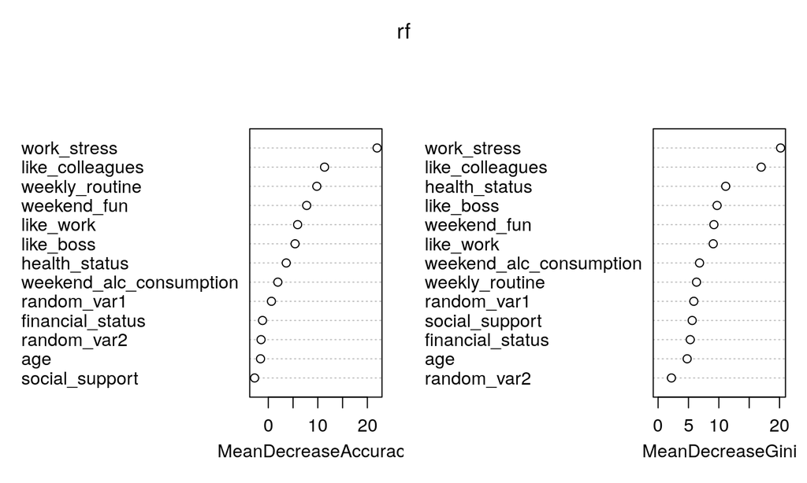

## Correlated predictors

Random forests can be sensitive to correlated predictors; this is particularly problematic when using random forest for variable selection. Some alternatives:

1. Conditional Inference Forests (`partykit::cforest`)
2. Boruta (`Boruta::Boruta`)

## Case of the Mondays, via treeheatr!

Check out [treeheatr](https://trang1618.github.io/treeheatr/) here!

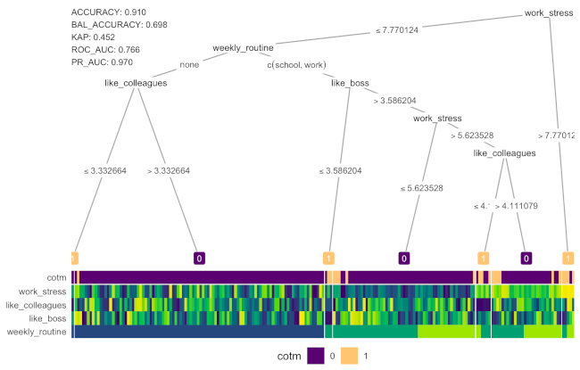

## References & Resources:

- [Elements of statistical learning](https://web.stanford.edu/~hastie/Papers/ESLII.pdf)
- [Leo Breiman: Random Forests, 2001 paper](https://www.stat.berkeley.edu/~breiman/randomforest2001.pdf)
- https://uc-r.github.io/random_forests
- https://www.blopig.com/blog/2017/04/a-very-basic-introduction-to-random-forests-using-r/